# The survival package

Abstract

“The survival package” published in R News.

This is another in our series of articles describing the recommended packages that come with the R distribution. The survival package is a port of code written by T. M. Therneau, of the Mayo Clinic, code that has also been part of S-PLUS for many years. Porting the survival package in 1997 was my introduction to R programming. It exposed quite a few bugs in R and incompatibilities with S (some of which, on reflection, might have been better left incompatible).

## Overview

Survival analysis, also called event history analysis in the social sciences and reliability analysis in engineering, is concerned with the time until an event occurs. The complication that makes survival analysis interesting is that individuals are often observed for only part of the relevant time period. They may be recruited well after time zero, and the study may end with only a small proportion of events having been seen.

In medical statistics the most common survival analyses are estimation of the distribution of time to the event, testing for equality of two distributions, and regression modelling of the rate at which events occur. These are all covered by the survival package.

Additional tools for regression modelling are in the Design and eha packages, and the muhaz package allows estimation of the hazard function (the analogue in survival analysis of density estimation).

## Specifying survival data

In the popular ‘counting process’ formulation of survival analysis each record in a dataset has three variables describing the survival time. A start variable specifies when observation begins, a stop variable specifies when it ends, and an event variable is 1 if observation ended with an event and 0 if it ended without seeing the event. These variables are bundled into a “Surv” object by the Surv() function. If the start variable is zero for everyone it may be omitted.

In data(veteran), time measures the time from the start of a lung cancer clinical trial and status is 1 if the patient died at time, 0 if follow-up ended with the patient still alive. In addition, diagtime gives the time from initial diagnosis until entry into the clinical trial.

```
> library(survival)
> data(veteran)
## time from randomisation to death
```

```
> with(veteran, Surv(time,status))
[1] 72 411 228 126 118 10 82
[8] 110 314 100+ 42 8 144 25+
...
```

```
## time from diagnosis to death
> with(veteran, Surv(diagtime*30,
                      diagtime*30+time,
                      status))
[1] ( 210, 282 ] ( 150, 561 ]
[3] ( 90, 318 ] ( 270, 396 ]
...
[9] ( 540, 854 ] ( 180, 280+]
...
```

The first “Surv” object prints the observation time, with a + to indicate that the event is still to come. The second object prints the start and end of observation, again using a + to indicate end of follow-up before an event.

### One and two sample summaries

The survfit() function estimates the survival distribution for a single group or multiple groups. It produces a “survfit” object with a plot() method. Figure 1 illustrates some of the options for producing more attractive graphs.

Two (or more) survival distributions can be compared with survdiff, which implements the logrank test (and the $G^\rho$ family of weighted logrank tests). In this example it is clear from the graphs and the tests that the new treatment (trt=2) and the standard treatment (trt=1) were equally ineffective.

```
> data(veteran)
> plot(survfit(Surv(time,status)~trt,data=veteran),
        xlab="Years since randomisation",
        xscale=365, ylab="% surviving", yscale=100,
        col=c("forestgreen","blue"))

> survdiff(Surv(time,status)~trt, data=veteran)
```

Call:  
survdiff(formula = Surv(time, status) ~ trt,  
data = veteran)

|  | N | Observed | Expected | (0-E)<sup>2</sup>/E |
| --- | --- | --- | --- | --- |
| trt=1 | 69 | 64 | 64.5 | 0.00388 |
| trt=2 | 68 | 64 | 63.5 | 0.00394 |
|  |  | (0-E)<sup>2</sup>/V |  |  |
| trt=1 |  | 0.00823 |  |  |
| trt=2 |  | 0.00823 |  |  |

Chisq= 0 on 1 degrees of freedom, p= 0.928

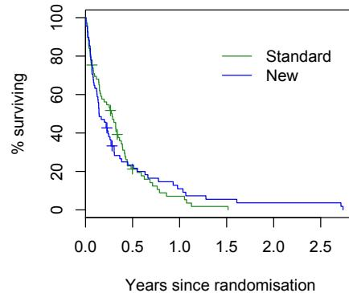

Figure 1: Survival distributions for two lung cancer treatments

## Proportional hazards models

The mainstay of survival analysis in the medical world is the Cox proportional hazards model and its extensions. This expresses the hazard (or rate) of events as an unspecified baseline hazard function multiplied by a function of the predictor variables.

Writing $h(t; z)$ for the hazard at time $t$ with predictor variables $Z = z$ the Cox model specifies

$$\log h(t, z) = \log h_0(t) e^{\beta
z}.$$

Somewhat unusually for a semiparametric model, there is very little loss of efficiency by leaving $h_0(t)$ unspecified, and computation is, if anything, easier than for parametric models.

A standard example of the Cox model is one constructed at the Mayo Clinic to predict survival in patients with primary biliary cirrhosis, a rare liver disease. This disease is now treated by liver transplantation, but at the same there was no effective treatment. The model is based on data from 312 patients in a randomised trial.

```
> data(pbc)
> mayomodel<-coxph(Surv(time,status)~edtrt+
    log(bili)+log(protime)+
    age+platelet,
    data=pbc, subset=trt>0)
> mayomodel
Call:
coxph(formula = Surv(time, status) ~ edtrt +
  log(bili) + log(protime) +
  age + platelet, data = pbc,
  subset = trt > 0)
```

|  | coef | exp(coef) |
| --- | --- | --- |
| edtrt | 1.02980 | 2.800 |
| log(bili) | 0.95100 | 2.588 |
| log(protime) | 2.88544 | 17.911 |

| age | 0.03544 | 1.036 |  |
| --- | --- | --- | --- |
| platelet | -0.00128 | 0.999 |  |
|  | se(coef) | z | p |
| edtrt | 0.300321 | 3.43 | 0.00061 |
| log(bili) | 0.097771 | 9.73 | 0.00000 |
| log(protime) | 1.031908 | 2.80 | 0.00520 |
| age | 0.008489 | 4.18 | 0.00003 |
| platelet | 0.000927 | -1.38 | 0.17000 |

Likelihood ratio test=185 on 5 df, $p=0$ $n= 312$

The `survexp` function can be used to compare predictions from a proportional hazards model to actual survival. Here the comparison is for 106 patients who did not participate in the randomised trial. They are divided into two groups based on whether they had edema (fluid accumulation in tissues), an important risk factor.

```
> plot(survfit(Surv(time,status)~edtrt,
  data=pbc,subset=trt== -9))
> lines(survexp(~edtrt+
  ratetable(edtrt=edtrt,bili=bili,
    platelet=platelet,age=age,
    protime=protime),
  data=pbc,
  subset=trt== -9,
  ratetable=mayomodel,
  cohort=TRUE),
  col="purple")
```

The `ratetable` function in the model formula wraps the variables that are used to match the new sample to the old model.

Figure 2 shows the comparison of predicted survival (purple) and observed survival (black) in these 106 patients. The fit is quite good, especially as people who do and do not participate in a clinical trial are often quite different in many ways.

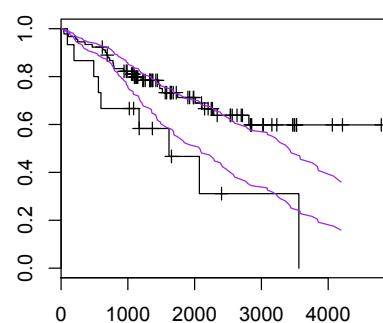

Figure 2: Observed and predicted survival

The main assumption of the proportional hazards model is that hazards for different groups are in fact proportional, *i.e.* that $\beta$ is constant over time. The `cox.zph` function provides formal tests and graphical diagnostics for proportional hazards

```
> cox.zph(mayomodel)
```

|  | rho | chisq | p |
| --- | --- | --- | --- |
| edtrt | -0.1602 | 3.411 | 0.0648 |
| log(bili) | 0.1507 | 2.696 | 0.1006 |
| log(protime) | -0.1646 | 2.710 | 0.0997 |
| age | -0.0708 | 0.542 | 0.4617 |
| platelet | -0.0435 | 0.243 | 0.6221 |
| GLOBAL | NA | 9.850 | 0.0796 |

```
## graph for variable 1 (edtrt)
> plot(cox.zph(mayomodel)[1])
```

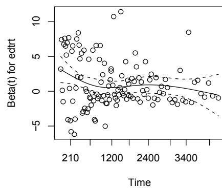

Figure 3: Testing proportional hazards

There is a suggestion that `edtrt` and `log(protime)` may have non-proportional hazards, and Figure 3 confirms this for `edtrt`. The curve shows an estimate of $\beta$ at each point in time, obtained by smoothing the residuals on the graph. It appears that `edtrt` is quite strongly predictive for the first couple of years but has little predictive power after that.

## Additional features

Computation for the Cox model extends straightforwardly to situations where $z$ can vary over time, and when an individual can experience multiple events of the same or different types. Interpretation of the parameters becomes substantially trickier, of course. The `coxph()` function allows formulas to contain a `cluster()` term indicating which records belong to the same individual and a `strata()` term indicating subgroups that get their own unspecified baseline hazard function.

Complementing `coxph` is `survreg`, which fits linear models for the mean of survival time or its logarithm with various parametric error distributions. The parametric models allow more flexible forms of censoring than does the Cox model.

More recent additions include penalised likelihood estimation for smoothing splines and for random effects models.

The survival package also comes with standard mortality tables for the US and a few individual states, together with functions for comparing the survival of a sample to that of a population and computing person-years of followup.

*Thomas Lumley*  
*Department of Biostatistics*  
*University of Washington, Seattle*